# Bookup quarto format example

Author

Jane Doe

Published

August 3, 2024

This is a sample document using the `bookup-html` custom [quarto](https://quarto.org) format.

You can learn more about this format and how to use it in the [bookup-html Github repository](https://github.com/juba/bookup-html).

# Code and tables

## Syntax highlighting

Here is a sample code chunk, just to show that syntax highlighting works as expected as well as code annotations.

```r
say_hello <- function(name) {
    paste("Hello,", name, "!")
}

say_hello("world")
```

**1**

Quite an original example.

**2**

This is were all the action is happening.

```
[1] "Hello, world !"
```

## Verbatim

Here is the structure of the `penguins` dataset.

```r
library(palmerpenguins)
str(penguins)
```

```
tibble [344 × 8] (S3: tbl_df/tbl/data.frame)
 $ species          : Factor w/ 3 levels "Adelie","Chinstrap",..: 1 1 1 1 1 1 1 1 1 1 ...
 $ island           : Factor w/ 3 levels "Biscoe","Dream",..: 3 3 3 3 3 3 3 3 3 3 ...
 $ bill_length_mm   : num [1:344] 39.1 39.5 40.3 NA 36.7 39.3 38.9 39.2 34.1 42 ...
 $ bill_depth_mm    : num [1:344] 18.7 17.4 18 NA 19.3 20.6 17.8 19.6 18.1 20.2 ...
 $ flipper_length_mm: int [1:344] 181 186 195 NA 193 190 181 195 193 190 ...
 $ body_mass_g      : int [1:344] 3750 3800 3250 NA 3450 3650 3625 4675 3475 4250 ...
 $ sex              : Factor w/ 2 levels "female","male": 2 1 1 NA 1 2 1 2 NA NA ...
 $ year             : int [1:344] 2007 2007 2007 2007 2007 2007 2007 2007 2007 2007 ...
```

## Tables

Sample table output.

```r
tab <- table(penguins$island, penguins$species)
kable(tab)
```

|  | Adelie | Chinstrap | Gentoo |
| --- | --- | --- | --- |
| Biscoe | 44 | 0 | 124 |
| Dream | 56 | 68 | 0 |
| Torgersen | 52 | 0 | 0 |

Sample `DT:datatable` output.

```r
library(DT)
DT::datatable(penguins)
```

|  | species | island | bill_length_mm | bill_depth_mm | flipper_length_mm | body_mass_g | sex | year |
| --- | --- | --- | --- | --- | --- | --- | --- | --- |
| 1 | Adelie | Torgersen | 39.1 | 18.7 | 181 | 3750 | male | 2007 |
| 2 | Adelie | Torgersen | 39.5 | 17.4 | 186 | 3800 | female | 2007 |
| 3 | Adelie | Torgersen | 40.3 | 18 | 195 | 3250 | female | 2007 |
| 4 | Adelie | Torgersen |  |  |  |  |  | 2007 |
| 5 | Adelie | Torgersen | 36.7 | 19.3 | 193 | 3450 | female | 2007 |
| 6 | Adelie | Torgersen | 39.3 | 20.6 | 190 | 3650 | male | 2007 |
| 7 | Adelie | Torgersen | 38.9 | 17.8 | 181 | 3625 | female | 2007 |
| 8 | Adelie | Torgersen | 39.2 | 19.6 | 195 | 4675 | male | 2007 |
| 9 | Adelie | Torgersen | 34.1 | 18.1 | 193 | 3475 |  | 2007 |
| 10 | Adelie | Torgersen | 42 | 20.2 | 190 | 4250 |  | 2007 |

[output cut: 334 more lines]

# Styling

A simple list :

- one mississipi
- two mississipi
- three mississipi

A blockquote :

> Oh ! What a nice blockquote you have here. Much more wonderful than a classical lorem ipsum, really.

And we could also [include links](https://www.r-project.org/) or simply URLs like this : https://www.r-project.org/[^1].

An incredibly complex equation :

$$y = \sqrt{\frac{1}{x + \beta}}$$

# Figures

Here is an histogram.

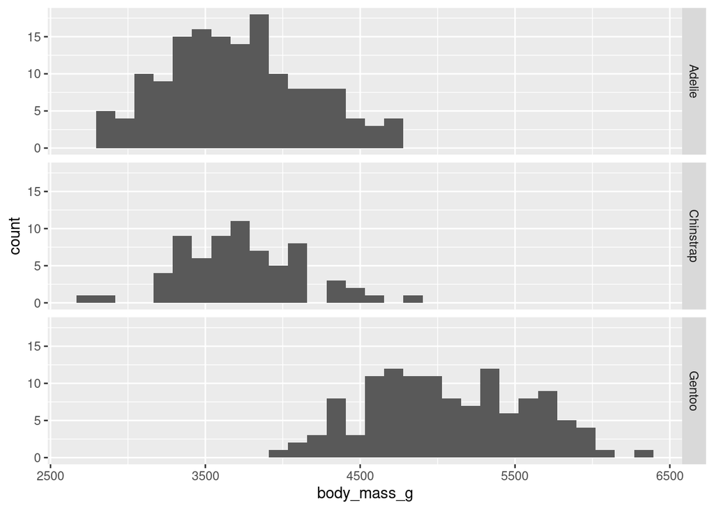

```r
library(ggplot2)
ggplot(data = penguins) +
    geom_histogram(aes(x = body_mass_g)) +
    facet_grid(rows = vars(species))
```

And a wonderful scatterplot, with a caption.

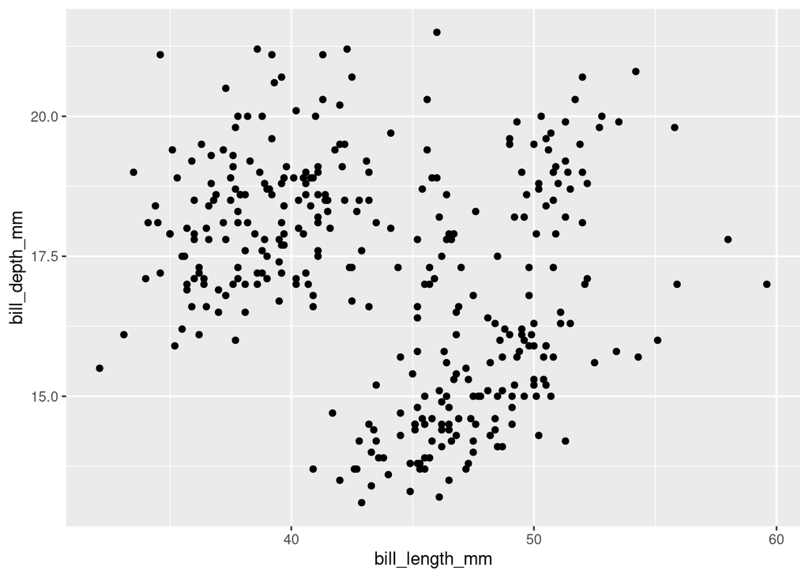

This is a scatterplot

```r
ggplot(data = penguins) +
    geom_point(
        aes(x = bill_length_mm, y = bill_depth_mm)
    )
```

# Callouts

**Note**

This is a note callout.

**Warning**

This is a warning callout

**Important**

This is an important callout

**Caution**

This is a caution callout

**Tip**

This is a tip callout.With a bit of `code`.

# Tabset

**First tab**

This is the first tab content.

**Second tab**

This is the second tab content.

## Footnotes

[^1]: And even footnotes